# hw8

Ty Darnell

November 26, 2018

# Problem 1

## Part a

```r
cnames=c("status", "N.total", "N.h", "N.c", "n.total", "n.h", "n.c")
dat=fread("HW8_Q1.txt")
colnames(dat)=cnames
```

Crude Death Rate per 100,000 operations

$\dfrac{100,000*deaths}{operations}$

halothane

$\dfrac{2375}{146200}*100,000=1624.487$ deaths per 100,000 operations

cyclopropane

$\dfrac{2109}{68169}*100,000=3093.782$ deaths per 100,000 operations

Using a Z-test for proportions to determine if the two rates are significantly different.

$\alpha=.05$

$H_0: \pi_1= \pi_2$

$H_A: \pi_1 \neq \pi_2$

```r
prop.test(x=c(2375,2109), n=c(146200,68169), alternative = "two.sided")
```

```
##
##  2-sample test for equality of proportions with continuity
##  correction
##
## data:  c(2375, 2109) out of c(146200, 68169)
## X-squared = 489.36, df = 1, p-value < 2.2e-16
## alternative hypothesis: two.sided
## 95 percent confidence interval:
##  -0.01615607 -0.01322982
## sample estimates:
##     prop 1     prop 2
## 0.01624487 0.03093782
```

Since p-value < $\alpha$ reject $H_0$

Conclude there is a significant differnce between the two rates.

## Part b

```r
dat%<>%mutate(p.h=n.h/N.h,p.c=n.c/N.c)

dat2=dat %>%
mutate(varProph = p.h*(1-p.h)/N.h,
varPropc = p.c*(1-p.c)/N.c,
weights = N.total/sum(N.total))

ans=dat2%>% summarize(stdProph = sum(p.h*weights),
          stdPropc = sum(p.c*weights),
          adjDiff = stdProph-stdPropc,
          varAdjDiff = sum(weights^2*(varProph+varPropc))/sum(weights)^2,
          Z = (adjDiff)/sqrt(varAdjDiff),
          pValue = pnorm(Z))

stdh=ans$stdProph*100000
stdc=ans$stdPropc*100000
```

Standardized Halothane = 1809.0620619

Standardized Cyclopropane = 2684.2854823

Using a Z-test to determine if the two rates are significantly different.

$\alpha=.05$

$H_0: \pi_{1_{adj}}= \pi_{2_{adj}}$

$H_A: \pi_{1_{adj}} \neq \pi_{2_{adj}}$

```r
kable(ans)
```

| stdProph | stdPropc | adjDiff | varAdjDiff | Z | pValue |
| --- | --- | --- | --- | --- | --- |
| 0.0180906 | 0.0268429 | -0.0087522 | 5e-07 | -12.42791 | 0 |

Reject $H_0$ since p-value$<\alpha$

Conclude the two standardized rates are not equal.

## Part c

```r
dati=dat %>%
mutate(refPop = n.total/N.total,
exp=N.h*refPop)
ans2=dati%>% summarize(o = sum(n.h),
            e=sum(exp),
            s = o/e,
            varO = o,
            varE = sum((N.h/N.total)^2*n.total),
            varS = (varO+s^2*varE)/e^2,
            Z = (s-1)/sqrt(varS),
            pVal = pnorm(Z))
```

```r
kable(ans2)
```

| o | e | s | varO | varE | varS | Z | pVal |
| --- | --- | --- | --- | --- | --- | --- | --- |
| 2375 | 2695.123 | 0.8812215 | 2375 | 848.2716 | 0.0004177 | -5.812032 | 0 |

```r
o=ans2$o
e=ans2$e
```

Using a Z-test to test whether $\pi_{halothane}/\pi_{overall}$=1

$\alpha=.05$

$\pi_{halothane}=$ 2375

$\pi_{overall}=$ 2695.1225166

Standardized Incidence Ratio =$s=\dfrac{O}{E}$

=$\pi_{halothane}/\pi_{overall}$=0.8812215

$H_0:\pi_{halothane}/\pi_{overall}=1$

$H_A:\pi_{halothane}/\pi_{overall}\neq 1$

$Var(s)=\dfrac{Var(O)+s^2Var(E)}{E^2}$ = 4.176566510^{-4}

Since 3.085948510^{-9} $<\alpha$

Reject $H_0$ conclude $\pi_{halothane}/\pi_{overall}\neq 1$

# Problem 2

## Part a

```r
sur=fread("HW8_SURV.txt")
cnames2=c("id","timedeath","death","age","group")
colnames(sur)=cnames2
```

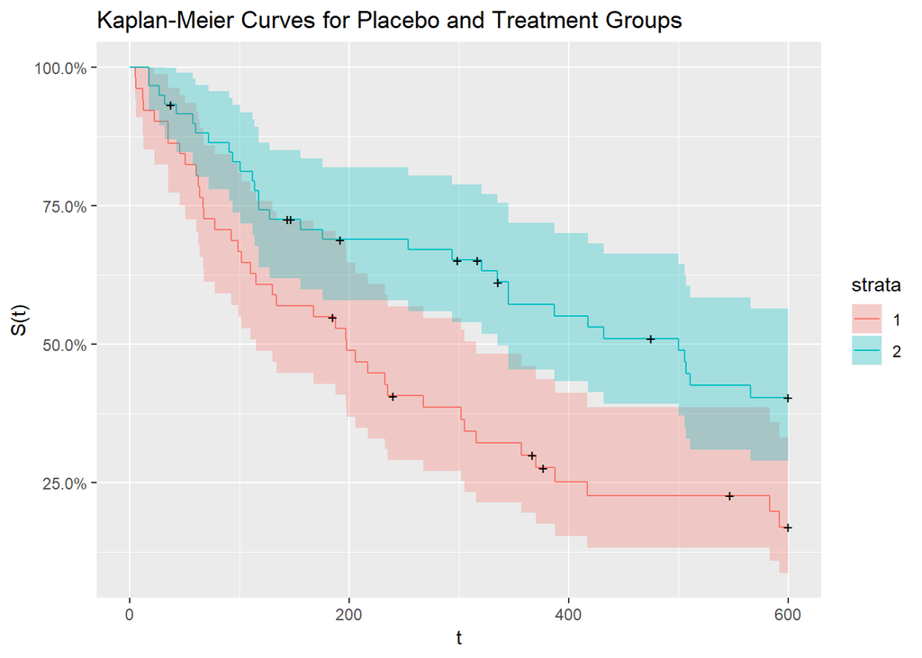

```r
sur2=sur%>%arrange(timedeath)
fit <- survfit(Surv(timedeath, death)~group,data=sur2)
autoplot(fit,xlab="t",ylab="S(t)",main = "Kaplan-Meier Curves for Placebo and Treatment Groups")
```

```r
summary(fit)
```

```
## Call: survfit(formula = Surv(timedeath, death) ~ group, data = sur2)
##
##                 group=1
##  time n.risk n.event survival std.err lower 95% CI upper 95% CI
##     5     51       1    0.980  0.0194        0.943        1.000
##     6     50       1    0.961  0.0272        0.909        1.000
##    12     49       1    0.941  0.0329        0.879        1.000
##    13     48       1    0.922  0.0376        0.851        0.998
##    23     47       1    0.902  0.0416        0.824        0.987
##    35     46       2    0.863  0.0482        0.773        0.963
##    46     44       1    0.843  0.0509        0.749        0.949
##    51     43       1    0.824  0.0534        0.725        0.935
##    61     42       1    0.804  0.0556        0.702        0.921
##    63     41       1    0.784  0.0576        0.679        0.906
##    64     40       1    0.765  0.0594        0.657        0.890
```

[output cut: 60 more lines]

## Part b

Log rank test to test whether the distribution of survival times is the same in the two groups.

$\alpha=.05$

$H_0: S_1(t)=S_2(t) \ \forall t$

$H_A: S_1(t)\neq S_2(t)$ for at least one t

```r
survdiff(Surv(timedeath, death)~group,data=sur2)
```

```
## Call:
## survdiff(formula = Surv(timedeath, death) ~ group, data = sur2)
##
##          N Observed Expected (O-E)^2/E (O-E)^2/V
## group=1 51       40     27.8      5.33      8.85
## group=2 59       32     44.2      3.36      8.85
##
##  Chisq= 8.8  on 1 degrees of freedom, p= 0.003
```

p-value=.003<$\alpha$

Reject $H_0$ since p-value< $\alpha$, thus $S_1(t)\neq S_2(t)$ for at least one t

## Part c

Using the proportional hazards model to test whether the distribution of survival times is the same in the two groups.

$\beta$=-0.6972

$\alpha=.05$

$H_0: \beta =0$

$H_A: \beta \neq 0$

```r
 phaz=coxph(Surv(timedeath, death)~group,data=sur2)
phaz
```

```
## Call:
## coxph(formula = Surv(timedeath, death) ~ group, data = sur2)
##
##          coef exp(coef) se(coef)      z       p
## group -0.6972    0.4980   0.2394 -2.913 0.00358
##
## Likelihood ratio test=8.54  on 1 df, p=0.003481
## n= 110, number of events= 72
```

pvalue=.00358<$\alpha$

Reject $H_0$ conclude the $\beta$ coefficient is significantly different from 0. Thus the distribution of survival times is not the same in the two groups.

## Part d

```r
conf=exp(confint(phaz))
```

Estimate for hazard ratio for group 2 relative to group 1= 0.4980

95% CI for the true hazards ratio: 0.3114788, 0.7960911

## Part e

```r
 phaz1=coxph(Surv(timedeath, death)~group+age,data=sur2)
phaz1
```

```
## Call:
## coxph(formula = Surv(timedeath, death) ~ group + age, data = sur2)
##
##           coef exp(coef) se(coef)      z       p
## group -0.72074   0.48639  0.24017 -3.001 0.00269
## age    0.04922   1.05045  0.02320  2.122 0.03387
##
## Likelihood ratio test=13.07  on 2 df, p=0.001451
## n= 110, number of events= 72
```

Adding age to the proportional hazards model

p-value for age=0.03387

since p-value < $\alpha$, age does have a signifcant effect on survival.

Adjusting for age does not make a substantial difference to the estimate of the treatment effect since the group coefiecient does not change substantially.